```python
from google.colab import drive
drive.mount("/content/drive")
```

```python
cd /content/drive/MyDrive/
```

```
/content/drive/MyDrive
```

# Chapter 1. 크롤링

## 문제 0. 기본 세팅

### (1) 크롤링에 필요한 라이브러리 모두 불러오기

```python
import numpy as np
import pandas as pd

from bs4 import BeautifulSoup
import time
import os
import requests

import selenium
from selenium import webdriver
from selenium.webdriver import ActionChains
from selenium.webdriver.common.keys import Keys
from selenium.webdriver.common.by import By
from selenium.webdriver.support import expected_conditions as EC
from selenium.webdriver.support.ui import Select
from selenium.webdriver.support.ui import WebDriverWait
from selenium.webdriver.chrome.options import Options
```

### (2) google colab 상에서 selenium으로 크롤링하기 위해 아래의 코드를 실행

```python
!pip install selenium
!apt-get update
!apt install chromium-chromedriver
```

## 문제 1. 매일경제 뉴스기사 크롤링 (2021년 10월 25일 오전 1시 기준)

### (1) 날짜 및 url 크롤링

본격적인 크롤링 전, 크롤링한 데이터를 저장해주기 위한 데이터프레임을 생성함.  
우선 날짜와 기사 링크에 대한 크롤링을 진행해야 하므로 데이터프레임에 날짜에 해당하는 date, 기사 링크에 해당하는 url 칼럼을 만들어 줌.

```python
article_df = pd.DataFrame(columns=[
    'date', 'url'
])
```

xpath를 통해 한 페이지에 뉴스 기사가 **25개**씩 있는 것을 확인할 수 있음.  
예를 들어, **//*[@id="container_left"]/div[3]/dl[1]**는 첫번째 페이지를 클릭했을 때 첫번째 기사에 대한 xpath를 나타내며,  
**//*[@id="container_left"]/div[3]/dl[25]**는 첫번째 페이지를 클릭했을 때 마지막 기사에 대한 xpath를 나타냄.  
마찬가지로, **//*[@id="container_left"]/div[3]/dl[1]**는 두번째 페이지를 클릭했을 때 첫번째 기사에 대한 xpath를 나타내며,  
**//*[@id="container_left"]/div[3]/dl[25]**는 두번째 페이지를 클릭했을 때 마지막 기사에 대한 xpath를 나타냄.

500개에 대한 크롤링을 진행해야 하고, 한 페이지에는 기사가 25개씩 존재하기 때문에 20페이지에 대한 크롤링을 진행해야 함. 앞에서 언급한 바와 같이 우리는 날짜와 기사 링크에 대한 크롤링을 진행해야 하는데, 기사 링크의 경우에는 xpath를 이용하여 크롤링을 진행하는 데 큰 문제가 없지만, 날짜의 경우에는 이미지의 존재 유무에 따라 xpath가 달라진다는 문제가 발생함. 따라서, 날짜는 예외 처리를 적용하며 크롤링을 해 주어야 함. (자새한 예외 처리 과정은 아래 코드의 주석을 참고해주세요!)

```python
chrome_options = webdriver.ChromeOptions()
chrome_options.add_argument('--headless')
chrome_options.add_argument('--no-sandbox')
chrome_options.add_argument('--disable-dev-shm-usage')

driver = webdriver.Chrome('chromedriver', options = chrome_options)
driver.maximize_window() # 창의 크기를 최대화

driver.get("https://www.mk.co.kr/news/stock/") # 크롤링을 시작할 웹사이트 주소 불러오기
driver.implicitly_wait(5) # 페이지 이동 시 다음 웹페이지 전체가 로딩될 때 까지 기다린 후, 5초가 지나면 웹페이지의 로딩 여부와 관계 없이 다음 명령어를 실행

# 500개를 크롤링 해야 하고, 한 페이지에는 기사가 25개씩 존재하므로 500/25 = 20페이지에 대한 크롤링을 진행해야 함
for page_idx in range(0, 20): # 파이썬에서는 마지막 인덱스는 포함하지 않는다는 점을 주의해야 함
    for article_idx in range(0, 25):

        # 아래와 같이 기사에서 이미지의 유무에 따라 date의 xpath가 달라지므로 예외처리 필요

        # 이미지 없는경우: date
        # f'//*[@id="container_left"]/div[3]/dl[{article_idx+1}]/dd/span[2]'

        # 이미지 있는경우: date
        # f'//*[@id="container_left"]/div[3]/dl[{article_idx+1}]/dd[2]/span[2]'

        # 예외처리 진행
        # 아래의 image가 구해진다면 해당 기사에 이미지가 존재하는 것임 -> 여기에서 dd인지, dd[2]인지가 결정된다
        try:
            image_exists = 1 # 우선 image_exists를 1로 설정
            # 이미지가 구해진다면, 아래의 if image_exist == 1로 넘어감
            image = driver.find_element_by_xpath(f'//*[@id="container_left"]/div[3]/dl[{article_idx+1}]/dd[1]/a/span')

        except:
            image_exists = 0 # 바로 위의 코드(try 내부의 코드)를 실행하였으나, 이미지가 구해지지 않았다면 image_exist의 값은 0으로 바뀜, 그리고 아래의 elif image_exist == 0으로 넘어감

        # 이미지가 존재하는 경우
        if  image_exists == 1:
            article_date = driver.find_element_by_xpath(f'//*[@id="container_left"]/div[3]/dl[{article_idx+1}]/dd[2]/span[2]').text # 해당 요소에서 텍스트만을 뽑아냄
            article_date = article_date[0:10] # 위의 xpath에서 텍스트를 뽑아내면 기사의 작성 시간까지 포함되지만, 우리는 날짜까지만 필요하므로 문자열에 대한 슬라이싱 진행

        elif image_exists == 0:
            article_date = driver.find_element_by_xpath(f'//*[@id="container_left"]/div[3]/dl[{article_idx+1}]/dd/span[2]').text # 해당 요소에서 텍스트만을 뽑아냄
            article_date = article_date[0:10] # 위의 xpath에서 텍스트를 뽑아내면 기사의 작성 시간까지 포함되지만, 우리는 날짜까지만 필요하므로 문자열에 대한 슬라이싱 진행

        # url은 예외 처리 불필요
        # 해당 xpath에 대한 href 값을 가져옴
        article_url = driver.find_element_by_xpath(f'//*[@id="container_left"]/div[3]/dl[{article_idx+1}]/dt/a').get_attribute('href')

        # 데이터프레임에 크롤링해온 요소 추가해주기
        article_df = article_df.append({'date' : article_date, 'url' : article_url}, ignore_index=True)

    # 다음 페이지로 넘어가기
    if page_idx+1 != 20: # 마지막 페이지가 아니라면
        if page_idx+1 == 10: # 10페이지의 경우 다음 페이지로 넘어가기 위해서는 숫자 버튼이 아닌 > 버튼을 눌러주어야 함
            next_page = driver.find_element_by_xpath('//*[@id="container_left"]/div[4]/a[11]') # > 버튼에 대한 xpath
            next_page.click() # 버튼 클릭
            time.sleep(3) # 페이지 이동 후 크롤러를 잠시 재워줌
        else:
            # 10페이지가 아닌 경우 다음 페이지로 넘어가기 위해서는 다음 페이지에 해당하는 숫자 버튼을 눌러주어야 함
            next_page = driver.find_element_by_xpath(f'//*[@id="container_left"]/div[4]/a[{(page_idx%10)+2}]')
            next_page.click()
            time.sleep(3) # 페이지 이동 후 크롤러를 잠시 재워줌
    else:
        driver.close() # 마지막 페이지에서 크롤링을 완료하였다면 크롤링 종료
```

데이터를 저장하지 않아 크롤링을 다시 하는 상황이 발생한다면 매우 슬플테니..데이터를 csv 파일로 저장하여 필요할 때 불러와서 사용함.

```python
article_df.to_csv("articles_date_url.csv", index = False, encoding = "utf-8")
```

### (2) 기사 제목 및 본문 크롤링

앞에서 크롤링 후 저장한 데이터를 불러와서 사용함.

```python
article_df = pd.read_csv("articles_date_url.csv", encoding = "utf-8")
```

앞에서 날짜와 기사 링크에 대한 크롤링 결과는 아래와 같음.

```python
article_df
```

|  | date | url |
| --- | --- | --- |
| 0 | 2021.10.24 | https://www.mk.co.kr/news/stock/view/2021/10/1... |
| 1 | 2021.10.24 | https://www.mk.co.kr/news/stock/view/2021/10/1... |
| 2 | 2021.10.24 | https://www.mk.co.kr/news/stock/view/2021/10/1... |
| 3 | 2021.10.24 | https://www.mk.co.kr/news/stock/view/2021/10/1... |
| 4 | 2021.10.24 | https://www.mk.co.kr/news/stock/view/2021/10/1... |
| ... | ... | ... |
| 495 | 2021.10.19 | https://www.mk.co.kr/news/stock/view/2021/10/9... |
| 496 | 2021.10.19 | https://www.mk.co.kr/news/stock/view/2021/10/9... |
| 497 | 2021.10.19 | https://www.mk.co.kr/news/stock/view/2021/10/9... |
| 498 | 2021.10.19 | https://www.mk.co.kr/news/stock/view/2021/10/9... |
| 499 | 2021.10.19 | https://www.mk.co.kr/news/stock/view/2021/10/9... |

500 rows × 2 columns

이번에는 앞에서 크롤링한 날짜와 url을 이용하여 기사의 제목과 본문 내용을 크롤링해야 함.  
크롤링 결과를 저장하기 위해 앞의 과정과 같이 데이터프레임을 생성하였고,  
날짜에 대한 칼럼 date, 기사 제목에 대한 칼럼 title, 본문 내용에 대한 칼럼 txt를 만들어 줌.

```python
article_contents_df = pd.DataFrame(columns=[
    'date', 'title', 'txt'
])
```

앞에서 크롤링한 데이터프레임을 이용하여 기사 제목과 본문에 대한 크롤링을 진행해야 함.  
따라서, 우선 앞에서 크롤링한 데이터프레임의 각 row에서 url을 가져와서 드라이버가 해당 사이트로 이동하도록 해 주어애 함.  
최종 데이터프레임은 날짜, 기사 제목, 본문 내용을 담고 있어야 하는데, 날짜는 앞에서 크롤링한 데이터프레임의 각 row에서 날짜를 그대로 가져오면 됨.  
기사 제목, 본문의 경우에는 가져온 url로 이동한 후 xpath를 찾아서 text만 뽑아주면 됨.  
앞에서 생성한 데이터프레임의 총 row 개수가 500개이므로 반복문을 이용하여 해결함.

```python
chrome_options = webdriver.ChromeOptions()
chrome_options.add_argument('--headless')
chrome_options.add_argument('--no-sandbox')
chrome_options.add_argument('--disable-dev-shm-usage')

driver = webdriver.Chrome('chromedriver', options = chrome_options)
driver.maximize_window()

for i in range(0, 500):
    url = driver.get(article_df['url'][i]) # 앞서 크롤링한 결과가 담긴 데이터프레임에서 i번째 row에 대한 url을 가져오고, 해당 url로 이동
    driver.implicitly_wait(5) # 페이지 이동 시 다음 웹페이지 전체가 로딩될 때 까지 기다린 후, 5초가 지나면 웹페이지의 로딩 여부와 관계 없이 다음 명령어를 실행

    article_date = article_df['date'][i] # 앞서 크롤링한 결과가 담긴 데이터프레임에서 i번째 row에 대한 날짜를 그대로 가져옴
    article_title = driver.find_element_by_xpath('//*[@id="top_header"]/div/div/h1').text # 해당 요소에서 텍스트만을 뽑아냄
    article_content = driver.find_element_by_xpath('//*[@id="article_body"]/div').text.replace('\n', '') # 해당 요소에서 텍스트만을 뽑아낸 후 줄바꿈 표시를 제거해 줌

    # 데이터프레임에 크롤링해온 요소 추가해주기
    article_contents_df = article_contents_df.append({'date' : article_date, 'title' : article_title, 'txt' : article_content}, ignore_index=True)

driver.close() # 크롤링 완료 후 드라이버 종료
```

역시 다시 크롤링 할 필요 없이 데이터를 필요할 때 마다 불러와서 사용해주기 위해 크롤링 결과를 csv 파일로 저장함.

```python
article_contents_df.to_csv("crawling_result.csv", index = False, encoding = "utf-8")
```

# Chapter 2. 워드클라우드

## 문제 1. 뉴스 기사 제목을 이용하여 워드클라우드 생성

형태소 분석을 통해 명사만 뽑아내야 하므로, 형태소 분석을 위한 konlpy를 설치함.

```python
!pip install konlpy
```

형태소 분석 및 워드클라우드 생성을 위해 필요한 모든 라이브러리를 불러옴.

```python
import numpy as np
import pandas as pd
import matplotlib.pyplot as plt

from wordcloud import WordCloud
from konlpy.tag import Okt
from collections import Counter
from PIL import Image
```

크롤링 최종 결과가 담긴 csv 파일을 불러옴.

```python
article_contents_df = pd.read_csv("crawling_result.csv", encoding = "utf-8")
```

크롤링의 최종 결과물은 아래와 같음.

```python
article_contents_df
```

|  | date | title | txt |
| --- | --- | --- | --- |
| 0 | 2021.10.24 | "히트송 하나 사서 연금처럼 받자"…음악저작권 사들이는 기업들 | 음악 저작권이 인수·합병(M&A) 시장의 뜨거운 키워드로 떠오르고 있다. 한국 드라... |
| 1 | 2021.10.24 | 테슬라 사상 최고가 경신…'천슬라' 눈앞 | 일론 머스크가 이끄는 미국 전기차 업체 테슬라 주가가 9개월 만에 900달러를 넘어... |
| 2 | 2021.10.24 | "일주일새 1천억" 개미들 돈 몰리는 이 ETF는 | 개인 투자자들이 지난 13일 거래소에 상장된 메타버스 관련 상장지수펀드(ETF)를 ... |
| 3 | 2021.10.24 | '긴축·인플레 공포' 전통자산은 안갯속…대체투자 큰손에 길묻다 | 코로나19 사태의 먹구름이 완전히 걷히기도 전에 전 세계 자금 긴축과 인플레이션(물... |
| 4 | 2021.10.24 | 코스피 주춤하자 동학개미 장외주식 기웃…전용앱도 봇물 | 올해 기업공개(IPO)가 활발하고 공모주시장이 달아오르면서 개인 투자자들의 비상장 ... |
| ... | ... | ... | ... |
| 495 | 2021.10.19 | 일동바이오사이언스, 기업공개 추진…2023년 상장 목표 | 일동바이오사이언스일동홀딩스[000230]의 계열사 일동바이오사이언스는 기업공개(IP... |
| 496 | 2021.10.19 | [아이넷 AI 로봇 기자] 특징주, 이노테라피-크래프톤 관련주 테마 상승세에 5.9... | 19일 크래프톤 관련주 테마가 전일 대비 3.74% 상승하면서 강세를 보이는 가운데... |
| 497 | 2021.10.19 | [아이넷 AI 로봇 기자] 특징주, TS인베스트먼트-크래프톤 관련주 테마 상승세에 ... | 19일 크래프톤 관련주 테마가 전일 대비 3.74% 상승하면서 강세를 보이는 가운데... |
| 498 | 2021.10.19 | "제 2의 오징어게임"…마이네임 흥행 조짐에 스튜디오산타클로스 급등 | [사진 출처 = 넷플릭스]넷플릭스 드라마 '마이네임'이 흥행 조짐을 보이면서 수혜주... |
| 499 | 2021.10.19 | [아이넷 AI 로봇 기자] 특징주, 실리콘투-2021 하반기 신규상장 테마 상승세에... | 19일 2021 하반기 신규상장 테마가 전일 대비 3.20% 상승하면서 강세를 보이... |

500 rows × 3 columns

형태소 분석을 위해 konlpy의 Okt()를 사용함 형태소 분석 후 명사만을 저장하기 위한 리스트인 nouns_list를 만들어 준 후,  
반복문을 이용하여 기사 제목 500개에 대한 형태소 분석을 시행함.  
okt.nouns("형태소 분석을 시행할 string") 메서드를 사용하면 해당 string에서 형태소 분석 시행 후 명사만을 반환해 줌.  
반환된 명사를 명사를 저장하기 위해 만들어준 리스트인 nouns_list에 계속 이어붙여줌.

```python
okt = Okt() # 형태소 분석기

nouns_list = [] # 명사를 저장해주기 위한 리스트 생성

for i in range(0, 500):
  nouns_list.extend(okt.nouns(article_contents_df['title'][i])) # i번째 기사의 제목에 대한 형태소 분석 후 명사만을 반환받고, 이를 리스트에 이어붙여줌
```

500개의 제목에서 명사만을 뽑아낸 결과는 아래와 같음.

```python
print(nouns_list)
```

```
['히트송', '하나', '사서', '연금', '음악', '저작권', '기업', '테슬라', '사상', '최고', '경신', '천슬', '눈앞', '일주일', '새', '개미', '돈', '이', '긴축', '인플레', '공포', '전통', '자산', '안갯속', '대체', '투자', '큰손', '길', '코스피', '주춤', '동학', '개미', '장외', '주식', '기웃', '전용', '앱', '봇물', '제품', '가격', '인상', '수혜', '기대', '식', '음료', '금리', '상승세', '급', '회사채', '수요…
```

명사의 등장 빈도 수를 기반으로 워드클라우드를 생성하기 위해, Counter()를 이용하여 명사의 등장 빈도에 대한 딕셔너리를 생성해 주었고,  
이를 nouns_freq 변수에 저장함.

```python
nouns_freq = Counter(nouns_list)
```

명사의 등장 빈도에 대한 딕셔너리 생성 결과는 아래와 같음.

```python
print(nouns_freq)
```

```
Counter({'아이': 228, '넷': 224, '로봇': 223, '기자': 223, '주': 206, '상승세': 175, '특징': 174, '테마': 169, '표': 57, '종목': 52, '상위': 43, '게임': 40, '코스닥': 38, '코스피': 36, '거래': 36, '등': 29, '기관': 26, '외국인': 26, '일': 26, '상승': 25, '업종': 23, '투자': 22, '대비': 22, '메타': 22, '버스': 22, '직전': 22, '다수': 22, '관련': 22, '증시'…
```

워드클라우드에서 한글이 깨지는 문제를 해결하기 위해서는 아래의 코드를 실행해야 함.  
워드클라우드를 그리기 위해 나눔폰트를 설치하는 과정을 거침.

```python
!apt-get update -qq
!apt-get install fonts-nanum* -qq
```

[output not shown]

폰트가 성공적으로 설치되었는지 확인하기 위해 matplotlib.font_manager를 불러온 후 아래의 코드를 실행함.  
설치된 나눔 폰트를 모두 확인한 후, 사용할 폰트의 path를 확인함.

```python
import matplotlib.font_manager as fm
sys_font = fm.findSystemFonts()
[f for f in sys_font if 'Nanum' in f]
```

```
['/usr/share/fonts/truetype/nanum/NanumBarunGothicUltraLight.ttf',
 '/usr/share/fonts/truetype/nanum/NanumBarunGothicLight.ttf',
 '/usr/share/fonts/truetype/nanum/NanumGothicCoding.ttf',
 '/usr/share/fonts/truetype/nanum/NanumGothicExtraBold.ttf',
 '/usr/share/fonts/truetype/nanum/NanumSquareRoundR.ttf',
 '/usr/share/fonts/truetype/nanum/NanumSquareRoundEB.ttf',
 '/usr/share/fonts/truetype/nanum/NanumSquareRoundL.ttf',
 '/usr/share/fonts/truetype/nanum/NanumBarunGothicBold.ttf',
 '/usr/share/fonts/truetype/nanum/NanumSquareEB.ttf',
 '/usr/share/fonts/truetype/nanum/NanumGothicLight.ttf',
 '/usr/share/fonts/truetype/nanum/NanumMyeongjoExtraBold.ttf',
 '/usr/share/fonts/truetype/nanum/NanumGothicEcoBold.ttf',
 '/usr/share/fonts/truetype/nanum/NanumGothic.ttf',
 '/usr/share/fonts/truetype/nanum/NanumGothicEcoExtraBold.ttf',
 '/usr/share/fonts/truetype/nanum/NanumPen.ttf',
 '/usr/share/fonts/truetype/nanum/NanumGothicBold.ttf',
 '/usr/share/fonts/truetype/nanum/NanumMyeongjoEcoExtraBold.ttf',
 '/usr/share/fonts/truetype/nanum/NanumGothicCoding-Bold.ttf',
 '/usr/share/fonts/truetype/nanum/NanumBarunpenR.ttf',
 '/usr/share/fonts/truetype/nanum/NanumBarunGothic.ttf',
 '/usr/share/fonts/truetype/nanum/NanumSquareL.ttf',
 '/usr/share/fonts/truetype/nanum/NanumMyeongjoEcoBold.ttf',
 '/usr/share/fonts/truetype/nanum/NanumSquareR.ttf',
 '/usr/share/fonts/truetype/nanum/NanumBrush.ttf',
 '/usr/share/fonts/truetype/nanum/NanumMyeongjoBold.ttf',
 '/usr/share/fonts/truetype/nanum/NanumGothicEco.ttf',
 '/usr/share/fonts/truetype/nanum/NanumBarunpenB.ttf',
 '/usr/share/fonts/truetype/nanum/NanumMyeongjo.ttf',
 '/usr/share/fonts/truetype/nanum/NanumSquareRoundB.ttf',
 '/usr/share/fonts/truetype/nanum/NanumMyeongjoEco.ttf',
 '/usr/share/fonts/truetype/nanum/NanumSquareB.ttf']
```

나눔고딕 ExtraBold 폰트를 워드클라우드에 이용하기로 결정하였고, 따라서 font_path에 해당 폰트의 path를 넣어줌.  
이는 이후 워드클라우드 생성 시 인자로 들어갈 것임.

```python
font_path = '/usr/share/fonts/truetype/nanum/NanumGothicExtraBold'
```

우선 불용어를 제거하지 않고 워드클라우드를 생성함.  
generate_from_frequencies의 경우 함수의 이름에서 알 수 있듯이 단어의 등장 빈도를 기반으로 하여 워드클라우드를 생성해 줌.  
이에 대한 인자로 앞에서 생성한 명사의 빈도에 대한 딕셔너리를 널어 줌.

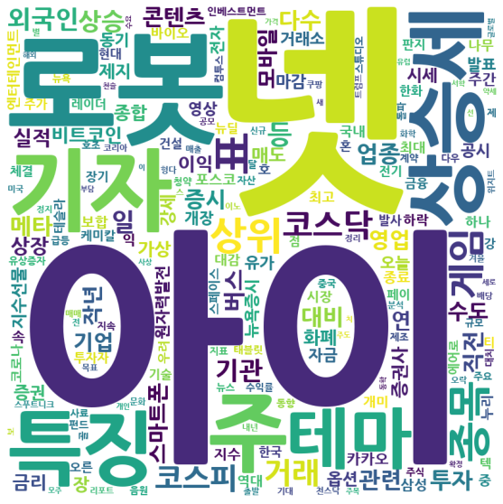

```python
wc = WordCloud(width = 800, height = 800,
              background_color ='white',
              font_path = font_path,
              min_font_size = 10)

wc.generate_from_frequencies(dict(nouns_freq))

plt.figure(figsize = (10, 10))
plt.imshow(wc)
plt.axis('off')
plt.show()
```

위의 워드클라우드 생성 결과를 보면 우선 가장 눈에 들어오는 부분이 '아이', '넷', '로봇', '기자'임.  
이런 상황이 발생하는 이유는 매일경제에 '아이넷 AI 로봇 기자'라는 것이 있으며,  
이 AI기자가 쓴 기사 앞에는 [아이넷 AI 로봇 기자]라는 표시가 붙기 때문임.  
따라서 이 string의 명사를 불용어로 지정해주어야 할 필요가 있음. 또한, 중간중간 의미가 없어 보이는 한 글자의 단어들이 포함된 것으로 보아 이러한 한 글자 단어들 역시 불용어로 지정해 주어야 함을 알 수 있음.

'아이넷 AI 로봇 기자'에 대한 명사 추출 결과는 다음과 같음.

```python
okt.nouns("아이넷 AI 로봇 기자")
```

```
['아이', '넷', '로봇', '기자']
```

한 글자 단어들을 모두 뽑아내기 위한 코드를 실행함.  
우선 한 글자 명사들을 저장할 리스트를 생성한 후, 앞에서 500개의 기사 제목에 대한 명사들을 모두 저장한 리스트에서 반복문과 조건문을 이용하여  
한 글자 명사들을 모두 뽑아내고 리스트에 계속 이어붙여 줌.

```python
unit_length_nouns = [] # 한 글자 명사를 저장하기 위핸 빈 리스트 생성

for noun in nouns_in_titles: # 500개의 기사 제목에 대란 모든 명사에 대한 검토 진행
    if len(noun) == 1: # 해당 명사가 한 글자라면
        unit_length_nouns.append(noun) # 앞에서 생성한 리스트에 이어붙여 줌
```

그런데, 단순히 이어 붙이기만 한다면 한 글자 명사가 중복되는 문제가 발생하므로, 한 글자 단어들이 저장된 리스트에서 유니크 값만 뽑아주어야 함.  
유나크 값을 뽑아낸 결과는 아래와 같음.

```python
np.unique(unit_length_nouns)
```

```
array(['감', '강', '개', '것', '게', '계', '골', '곳', '과', '광', '국', '글', '급',
       '길', '내', '넷', '눈', '느', '단', '달', '더', '데', '뎁', '도', '돈', '등',
       '디', '때', '또', '뚝', '랩', '량', '령', '로', '론', '리', '메', '및', '밖',
       '배', '백', '법', '별', '보', '분', '브', '비', '빅', '빈', '뿔', '상', '새',
       '샘', '선', '세', '셀', '속', '손', '수', '스', '식', '신', '썸', '씨', '알',
       '앤', '앱', '엠', '연', '온', '옵', '왜', '월', '위', '의', '이', '익', '인',
       '일', '임', '입', '자', '장', '전', '점', '제', '젠', '젤', '종', '주', '중',
       '차', '첫', '치', '터', '텍', '투', '트', '티', '판', '팝', '펄', '펫', '폭',
       '표', '피', '픽', '항', '헬', '호', '혼', '회', '후', '힘'], dtype='<U1')
```

"아이넷 AI 로봇 기자"의 명사 리스트를 우선 불용어 리스트인 stop_words_list에 저장한 후,  
한 글자 단어들의 unique값이 담긴 array를 리스트로 변환 후 stop_words_list에 이어붙여 줌.

```python
stop_words_list = okt.nouns("아이넷 AI 로봇 기자")
stop_words_list.extend(np.unique(unit_length_nouns).tolist())
```

최종 불용어 리스트는 아래와 같음.

```python
print(stop_words_list)
```

```
['아이', '넷', '로봇', '기자', '감', '강', '개', '것', '게', '계', '골', '곳', '과', '광', '국', '글', '급', '길', '내', '넷', '눈', '느', '단', '달', '더', '데', '뎁', '도', '돈', '등', '디', '때', '또', '뚝', '랩', '량', '령', '로', '론', '리', '메', '및', '밖', '배', '백', '법', '별', '보', '분', '브', '비', '빅', '빈', '뿔', '상', '새', '샘', '선', '세', '…
```

앞에서 언급한 바와 같이 generate_from_frequencies는 단어의 빈도 수를 기반으로 워드클라우드를 생성함. 그런데, generate_from_text는 WordCloud()의 인자로 불용어들을 받아 불용어를 제거해 줄 수 있지만, generate_from_frequencies의 경우에는 WordCloud()에 불용어들을 인자로 전달해주더라도 불용어 제거가 되지 않음.  
따라서, 원래의 기사 500개의 제목에서 명사만 추출한 리스트에서 불용어를 직접 제거해 준 후, 이 필터링한 리스트를 이용해서 워드클라우드를 만들어야 함.  
아래와 같이 불용어를 필터링한 리스트를 생성해 주었고, 이를 이용하여 워드클라우드를 생성할 것임.

```python
nouns_filtered = [noun for noun in nouns_in_titles if noun not in stop_words_list]
```

필터링된 리스트는 아래와 같음.

```python
print(nouns_filtered)
```

```
['히트송', '하나', '사서', '연금', '음악', '저작권', '기업', '테슬라', '사상', '최고', '경신', '천슬', '눈앞', '일주일', '개미', '긴축', '인플레', '공포', '전통', '자산', '안갯속', '대체', '투자', '큰손', '코스피', '주춤', '동학', '개미', '장외', '주식', '기웃', '전용', '봇물', '제품', '가격', '인상', '수혜', '기대', '음료', '금리', '상승세', '회사채', '수요', '미달', '속출', '오늘', '레이더', '뉴스', '…
```

역시, 각 명사의 빈도수를 계산해 주어야 하므로 Counter()를 이용하여 명사의 빈도수에 대한 딕셔너리를 생성함.  
이를 nouns_filtered_freq 변수에 저장함.

```python
nouns_filtered_freq = Counter(nouns_filtered)
```

필터링한 명사 리스트를 이용하여 워드클라우드를 생성한 결과는 아래와 같음.

[figure not shown]

```python
wc = WordCloud(width = 800, height = 800,
              background_color ='white',
              font_path = font_path,
              min_font_size = 10)

wc.generate_from_frequencies(dict(nouns_filtered_freq))

plt.figure(figsize = (10, 10))
plt.imshow(wc)
plt.axis('off')
plt.show()
```

워드클라우드에 모양을 넣어주기 위해 드라이브에서 이미지를 불러옴.  
이를 mask로 저장하였고, 이후 워드클라우드 생성 시 mask는 워드클라우드의 인자로 전달될 것임.

```python
img = Image.open('최고심3.png')
img = img.resize((2000,2000))
mask = np.array(img)
```

위의 mask를 인자로 전달하여 **고심이 모양의 워드클라우드**를 생성함!  
고심이>_< 무슨 이모티콘인지 맞춰보세용ㅎㅎ..

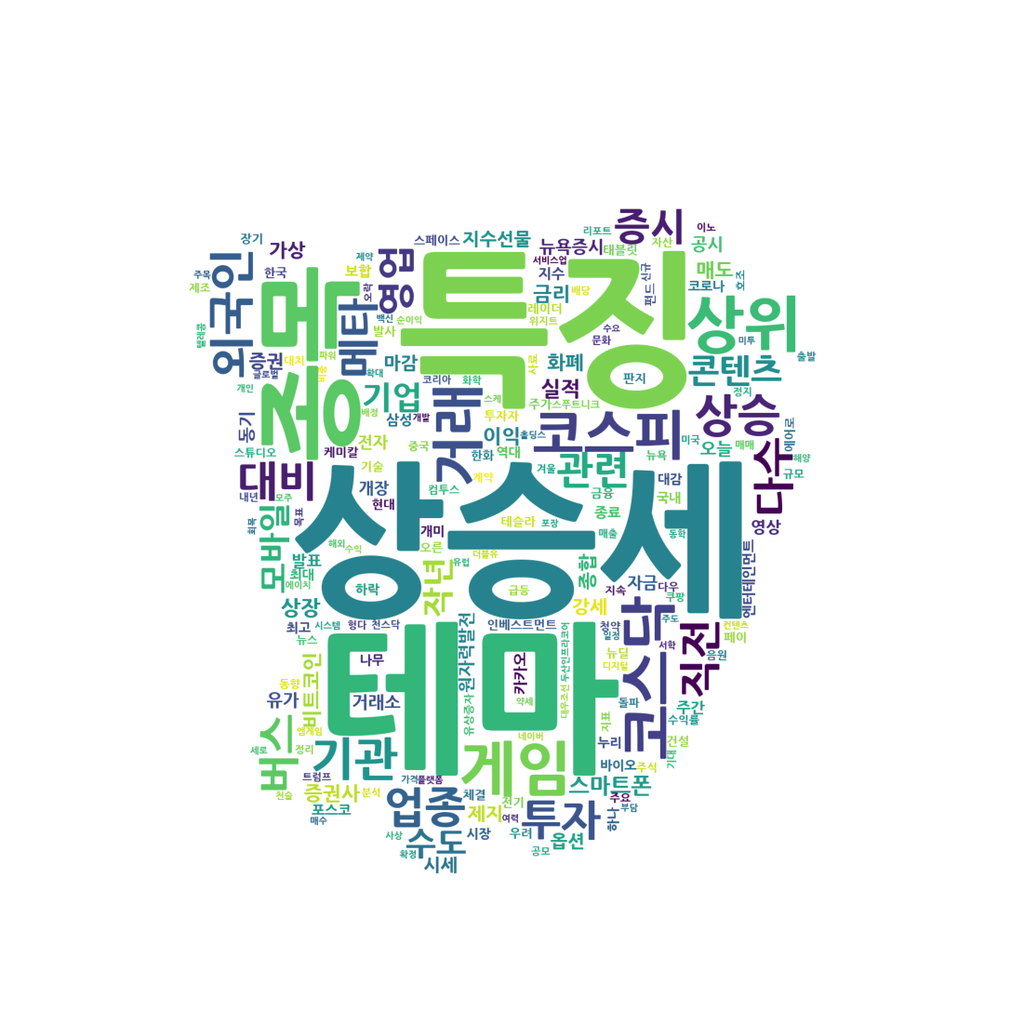

```python
wc = WordCloud(width = 2000, height = 2000,
              background_color ='white',
              font_path = font_path,
              mask = mask,
              min_font_size = 10)

wc.generate_from_frequencies(dict(nouns_filtered_freq))

plt.figure(figsize = (20, 20))
plt.imshow(wc)
plt.axis('off')
plt.show()
```

## 문제 2. 워드클라우드를 통해 파악 가능한 인사이트

주식 / 경제 관련 기사 섹션에 맞게 우선 주식 / 경제 분야와 관련된 단어들이 다수 보이는 것을 확인할 수 있다.  
우선 주식의 상승세에 대한 기사가 다수 존재함을 알 수 있다.  
또한, 주식의 특징 테마에 대한 기사도 다수 존재함을 알 수 있다.  
더불어 요즘 이슈가 되고 있는 메타버스에 대한 키워드 역시 워드클라우드에 존재함을 확인할 수 있다.